# DS_Assignment_7

Ankit

03/12/2021

# 1. Titanic: What Happened During Her Last Hours?

```r
library(tidyverse)
library(margins)
library(modeest)
```

## 1.1 Titanic Data

### 1.1.1 Load file titanic.csv, and do quick sanity checks.

```r
titanic <- read.csv('titanic (1).csv.bz2')
head(titanic,10)
```

```
##    pclass survived                                            name    sex
## 1       1        1                   Allen, Miss. Elisabeth Walton female
## 2       1        1                  Allison, Master. Hudson Trevor   male
## 3       1        0                    Allison, Miss. Helen Loraine female
## 4       1        0            Allison, Mr. Hudson Joshua Creighton   male
## 5       1        0 Allison, Mrs. Hudson J C (Bessie Waldo Daniels) female
## 6       1        1                             Anderson, Mr. Harry   male
## 7       1        1               Andrews, Miss. Kornelia Theodosia female
## 8       1        0                          Andrews, Mr. Thomas Jr   male
## 9       1        1   Appleton, Mrs. Edward Dale (Charlotte Lamson) female
## 10      1        0                         Artagaveytia, Mr. Ramon   male
##        age sibsp parch   ticket     fare   cabin embarked boat body
## 1  29.0000     0     0    24160 211.3375      B5        S    2   NA
## 2   0.9167     1     2   113781 151.5500 C22 C26        S   11   NA
## 3   2.0000     1     2   113781 151.5500 C22 C26        S        NA
```

[output cut: 18 more lines]

```r
summary(titanic) #No major issue with the dataset except missing values in multiple columns.
```

```
##      pclass         survived         name               sex
##  Min.   :1.000   Min.   :0.000   Length:1309        Length:1309
##  1st Qu.:2.000   1st Qu.:0.000   Class :character   Class :character
##  Median :3.000   Median :0.000   Mode  :character   Mode  :character
##  Mean   :2.295   Mean   :0.382
##  3rd Qu.:3.000   3rd Qu.:1.000
##  Max.   :3.000   Max.   :1.000
##
##       age              sibsp            parch          ticket
##  Min.   : 0.1667   Min.   :0.0000   Min.   :0.000   Length:1309
##  1st Qu.:21.0000   1st Qu.:0.0000   1st Qu.:0.000   Class :character
##  Median :28.0000   Median :0.0000   Median :0.000   Mode  :character
##  Mean   :29.8811   Mean   :0.4989   Mean   :0.385
##  3rd Qu.:39.0000   3rd Qu.:1.0000   3rd Qu.:0.000
##  Max.   :80.0000   Max.   :8.0000   Max.   :9.000
##  NA's   :263
##       fare            cabin             embarked             boat
##  Min.   :  0.000   Length:1309        Length:1309        Length:1309
##  1st Qu.:  7.896   Class :character   Class :character   Class :character
##  Median : 14.454   Mode  :character   Mode  :character   Mode  :character
##  Mean   : 33.295
##  3rd Qu.: 31.275
##  Max.   :512.329
##  NA's   :1
##       body        home.dest
##  Min.   :  1.0   Length:1309
##  1st Qu.: 72.0   Class :character
##  Median :155.0   Mode  :character
##  Mean   :160.8
##  3rd Qu.:256.0
##  Max.   :328.0
##  NA's   :1188
```

### 1.1.2 Find the number of missings in the important variables. You are definitely going to use variables survived, pclass, sex, age, and you may use more (see below).

```r
#Some important variables are: survived, pclass, sex, age, and fare.

sapply(titanic[,c('survived','pclass','sex','age','fare')], function(x) sum(is.na(x)))
```

```
## survived   pclass      sex      age     fare
##        0        0        0      263        1
```

### 1.1.3

Implausible values across all the columns:

From the selected columns, 3 columns: Survived, pclass and sex are categorical variables which cannot have implausible values. Hence looking at the summary of two columns: age and fare.

Fare: This variable has an implausible value. The maximum value of the column is 512, where as the mean is 33 and median is 14.

Age: Age has some values which are way above then mean and median age of the people who were in titanic but we cannot say that these are implausible values as there can be older people on titanic and 80(max age) is not an implausible value.

```r
summary(titanic[,c('fare','age')])
```

```
##       fare              age
##  Min.   :  0.000   Min.   : 0.1667
##  1st Qu.:  7.896   1st Qu.:21.0000
##  Median : 14.454   Median :28.0000
##  Mean   : 33.295   Mean   :29.8811
##  3rd Qu.: 31.275   3rd Qu.:39.0000
##  Max.   :512.329   Max.   :80.0000
##  NA's   :1         NA's   :263
```

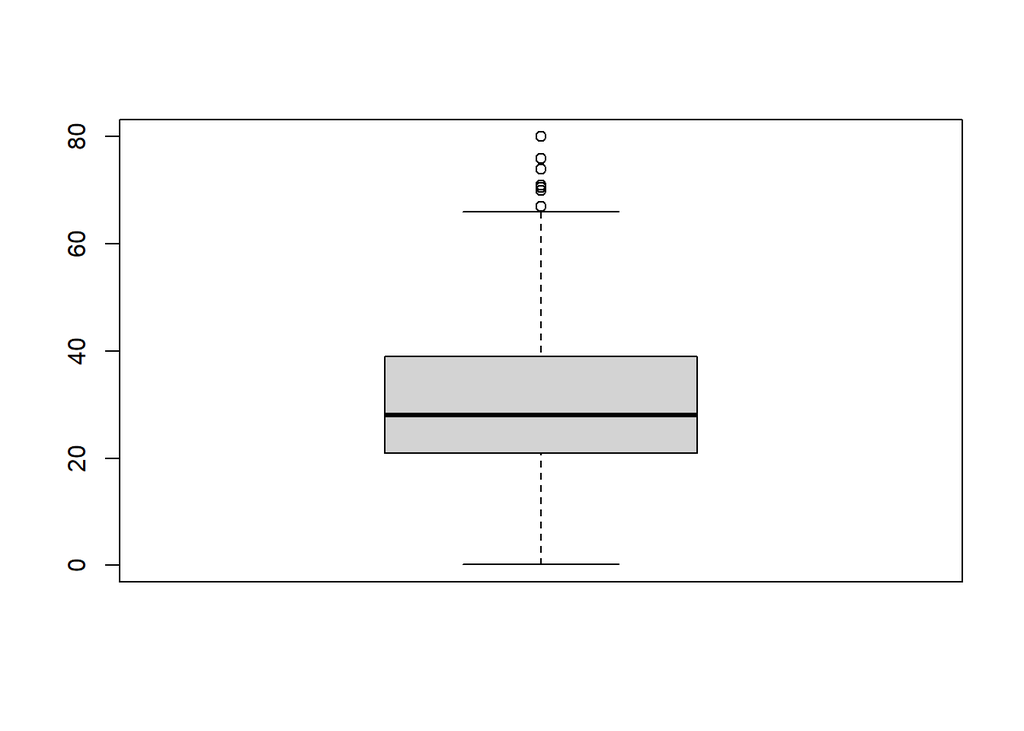

```r
boxplot(titanic$age) #boxplot to see outliers in age variables
```

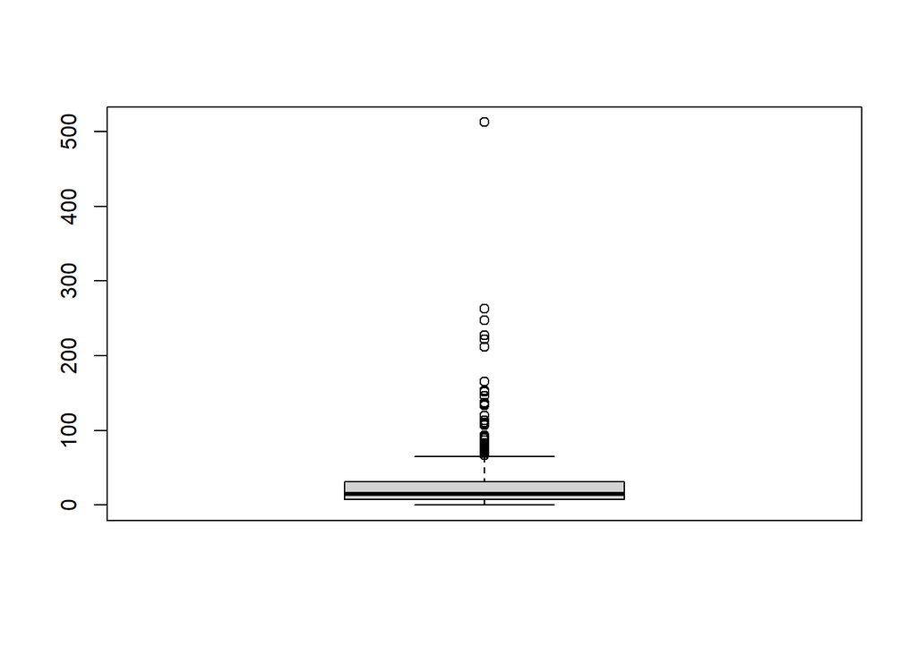

```r
boxplot(titanic$fare) #boxplot to see outliers in age variables
```

## 1.2 Logistic Regression

### 1.2.1 Based on the survivors accounts, which variables do you think are the most important ones to describe survival? How should those be related to the survival? (should they increase or decrease chances of survival?)

- Based on the survivors’ accounts, most important variables to describe survival are age, sex, and pclass.
- It was told in the survivors’ account that women and children were given preference over men. Class 1 and class 2 people were considered for the survival efforts as it was difficult for class 3 to reach the top of the deck and received less direction and were not able to easily understand the language
- It is given that women have higher chances of survival than men i.e. women are positively associated with chance of survival while men are negatively associated with the chance of survival.
- Similarly, class 1 and class 2 people are positively associated with chance of survival while class 3 are negatively associated with the chance of survival.

### 1.2.2 Create a new variable child, that is 1 if the passenger was younger than 14 years old.

```r
titanic <- titanic%>% mutate(child = ifelse(age<14,1,0))
head(titanic,10)
```

```
##    pclass survived                                            name    sex
## 1       1        1                   Allen, Miss. Elisabeth Walton female
## 2       1        1                  Allison, Master. Hudson Trevor   male
## 3       1        0                    Allison, Miss. Helen Loraine female
## 4       1        0            Allison, Mr. Hudson Joshua Creighton   male
## 5       1        0 Allison, Mrs. Hudson J C (Bessie Waldo Daniels) female
## 6       1        1                             Anderson, Mr. Harry   male
## 7       1        1               Andrews, Miss. Kornelia Theodosia female
## 8       1        0                          Andrews, Mr. Thomas Jr   male
## 9       1        1   Appleton, Mrs. Edward Dale (Charlotte Lamson) female
## 10      1        0                         Artagaveytia, Mr. Ramon   male
##        age sibsp parch   ticket     fare   cabin embarked boat body
## 1  29.0000     0     0    24160 211.3375      B5        S    2   NA
## 2   0.9167     1     2   113781 151.5500 C22 C26        S   11   NA
## 3   2.0000     1     2   113781 151.5500 C22 C26        S        NA
```

[output cut: 18 more lines]

### 1.2.3 Explain why do we have to treat pclass as categorical. Convert it to categorical using factor(pclass).

pclass in titanic dataset is of integer datatype. If we see the unique values of pclass there are only 3 values: 1,2 and 3. This means that in titanic there were only 3 classes(categories) in which people can buy ticket. Hence, we can say that this variable should be a categorical variable.

```r
class(titanic$pclass) #integer
```

```
## [1] "integer"
```

```r
unique(titanic$pclass)
```

```
## [1] 1 2 3
```

```r
titanic$pclass <- as.factor(titanic$pclass)
class(titanic$pclass)
```

```
## [1] "factor"
```

### 1.2.4 Estimate a multiple logistic regression model where you explain survival by these variables. Show the results

#### Logistic regression models:

```r
t <- titanic[,c('survived','pclass','sex','age','fare','child')] #selecting important variables
head(t,5)
```

```
##   survived pclass    sex     age     fare child
## 1        1      1 female 29.0000 211.3375     0
## 2        1      1   male  0.9167 151.5500     1
## 3        0      1 female  2.0000 151.5500     1
## 4        0      1   male 30.0000 151.5500     0
## 5        0      1 female 25.0000 151.5500     0
```

```r
model1 <- glm(survived ~ age+pclass+sex+fare+child, data=t, family=binomial()) #building logistic regression model
summary(model1)
```

```
##
## Call:
## glm(formula = survived ~ age + pclass + sex + fare + child, family = binomial(),
##     data = t)
##
## Deviance Residuals:
##     Min       1Q   Median       3Q      Max
## -2.7408  -0.7104  -0.4283   0.6624   2.3675
##
## Coefficients:
##               Estimate Std. Error z value Pr(>|z|)
## (Intercept)  3.1766153  0.4071740   7.802 6.11e-15 ***
## age         -0.0264856  0.0075672  -3.500 0.000465 ***
## pclass2     -1.2183959  0.2549213  -4.779 1.76e-06 ***
## pclass3     -2.2266747  0.2649851  -8.403  < 2e-16 ***
## sexmale     -2.4993239  0.1676343 -14.909  < 2e-16 ***
## fare         0.0001538  0.0017759   0.087 0.930965
## child        0.5854273  0.3209272   1.824 0.068126 .
## ---
## Signif. codes:  0 '***' 0.001 '**' 0.01 '*' 0.05 '.' 0.1 ' ' 1
##
## (Dispersion parameter for binomial family taken to be 1)
##
##     Null deviance: 1413.57  on 1044  degrees of freedom
## Residual deviance:  979.01  on 1038  degrees of freedom
##   (264 observations deleted due to missingness)
## AIC: 993.01
##
## Number of Fisher Scoring iterations: 4
```

```r
me1 <- margins(model1)  #marginalizing the model output to interpret the model.
summary(me1)
```

```
##   factor     AME     SE        z      p   lower   upper
##      age -0.0040 0.0011  -3.5637 0.0004 -0.0062 -0.0018
##    child  0.0884 0.0483   1.8322 0.0669 -0.0062  0.1830
##     fare  0.0000 0.0003   0.0866 0.9310 -0.0005  0.0005
##  pclass2 -0.2149 0.0438  -4.9038 0.0000 -0.3008 -0.1290
##  pclass3 -0.3714 0.0425  -8.7488 0.0000 -0.4547 -0.2882
##  sexmale -0.4869 0.0283 -17.2175 0.0000 -0.5423 -0.4315
```

### 1.2.5 Interpret the results. Did men or women, old or young have larger chances of survival? What about different passenger classes? How big were the effects?

**Women or Men:** If we look at model, we can clearly see that males are 48% point less likely to survive when compared to females.

**Old or Young:** If we look at model, we can clearly see that young population (age<14) on titanic are 8.8% point more likely to survive when compared to old population (age>14)

**Passanger classes:** If we look at model, we can clearly see that people in passanger class 3 on titanic are 37% point less likely to survive where as people in passanger class 2 on are 21% less likely to survive when compared to people in passanger class 1.

**Age:** If we look at model, we can see that for every increase in 1 year of age, the odds of surviving decreases by 0.4% points.

**Fare:** If we look at model, we can see that for every 1 unit increase in fare, the odds of surviving increses by ~0.0%

### 1.2.6 But what about young men? Were they able to force their way to the boats? Create a variable “young man” (e.g. males between 18 and 35, or anything else you see suitable) and see if they survived more likely than others.

```r
t <- t%>% mutate(young_men = ifelse((age>18 & age<35)&((sex %in% "male")),1,0))
```

```r
model <- glm(survived ~ age+pclass+sex+fare+child+young_men, data=t, family=binomial())
summary(model)
```

```
##
## Call:
## glm(formula = survived ~ age + pclass + sex + fare + child +
##     young_men, family = binomial(), data = t)
##
## Deviance Residuals:
##     Min       1Q   Median       3Q      Max
## -2.7797  -0.7268  -0.4487   0.6737   2.4121
##
## Coefficients:
##               Estimate Std. Error z value Pr(>|z|)
## (Intercept)  3.0625780  0.4196335   7.298 2.92e-13 ***
## age         -0.0225092  0.0083345  -2.701  0.00692 **
## pclass2     -1.2488093  0.2579041  -4.842 1.28e-06 ***
## pclass3     -2.2490348  0.2669159  -8.426  < 2e-16 ***
## sexmale     -2.6549109  0.2147707 -12.362  < 2e-16 ***
## fare         0.0001488  0.0017954   0.083  0.93395
## child        0.8018925  0.3735340   2.147  0.03181 *
## young_men    0.2960639  0.2467757   1.200  0.23024
## ---
## Signif. codes:  0 '***' 0.001 '**' 0.01 '*' 0.05 '.' 0.1 ' ' 1
##
## (Dispersion parameter for binomial family taken to be 1)
##
##     Null deviance: 1413.57  on 1044  degrees of freedom
## Residual deviance:  977.55  on 1037  degrees of freedom
##   (264 observations deleted due to missingness)
## AIC: 993.55
##
## Number of Fisher Scoring iterations: 4
```

```r
me <- margins(model)
summary(me)
```

```
##     factor     AME     SE        z      p   lower   upper
##        age -0.0034 0.0012  -2.7298 0.0063 -0.0058 -0.0010
##      child  0.1209 0.0560   2.1600 0.0308  0.0112  0.2306
##       fare  0.0000 0.0003   0.0829 0.9340 -0.0005  0.0006
##    pclass2 -0.2199 0.0440  -4.9922 0.0000 -0.3062 -0.1336
##    pclass3 -0.3757 0.0427  -8.7937 0.0000 -0.4594 -0.2920
##    sexmale -0.5140 0.0352 -14.6220 0.0000 -0.5829 -0.4451
##  young_men  0.0446 0.0371   1.2023 0.2292 -0.0281  0.1174
```

# 2. Predict AirBnB Price

### 2.1 Load the data. Select only relevant variables you need below, otherwise the dataset is hard to comprehend. Do basic sanity checks.

```r
airbnb <- read.csv('airbnb-vancouver-bc-listings.csv.bz2') #load the data
```

```r
dim(airbnb) #dimensions of the data frame
```

```
## [1] 4448   74
```

```r
airbnb <- airbnb %>% select(price, bedrooms, room_type, accommodates)  #selecting necessary columns
head(airbnb)
```

```
##     price bedrooms       room_type accommodates
## 1 $158.00        2 Entire home/apt            5
## 2 $150.00       NA Entire home/apt            4
## 3  $85.00        1 Entire home/apt            2
## 4 $149.00        1 Entire home/apt            2
## 5 $150.00        1 Entire home/apt            4
## 6 $350.00        2 Entire home/apt            4
```

```r
summary(airbnb)  #No major issue with the dataset except missing values in bedrooms.
```

```
##     price              bedrooms       room_type          accommodates
##  Length:4448        Min.   : 1.000   Length:4448        Min.   : 1.000
##  Class :character   1st Qu.: 1.000   Class :character   1st Qu.: 2.000
##  Mode  :character   Median : 1.000   Mode  :character   Median : 3.000
##                     Mean   : 1.601                      Mean   : 3.427
##                     3rd Qu.: 2.000                      3rd Qu.: 4.000
##                     Max.   :13.000                      Max.   :16.000
##                     NA's   :312
```

### 2.2 Do the basic data cleaning:

#### 2.2.a Convert price to numeric.

```r
airbnb$price1 <- gsub(",","",as.character(airbnb$price))  #removing ","
airbnb$price <- as.numeric(gsub("[^0-9\\..]","",airbnb$price1))  #removing "$" sign
```

#### 2.2.b Remove entries with missing or invalid price, bedrooms, and other variables you need below

```r
sapply(airbnb, function(x) sum(is.na(x))*100/dim(airbnb)[1])  #7% of the values in bedrooms are null hence replacing null.
```

```
##        price     bedrooms    room_type accommodates       price1
##     0.000000     7.014388     0.000000     0.000000     0.000000
```

```r
unique(airbnb[rowSums(is.na(airbnb)) > 0,]$room_type) # Entire home/apt and private rooms have bedrooms as null.
```

```
## [1] "Entire home/apt" "Private room"
```

As we can see from the above code, **bedrooms** column has null values. Within the column, only *Entire home/apt* and *Private room* have null values.

As, bedroom is a categorical variable and NULL values% is only 7%, I am replacing NULL values based on the the categorization of the column.

For “Entire home/apt” I am replacing NULL values with 0 as they could be “Studio apartment” and similarly “Private Room” could be in a studio apartment which also makes the bedroom count 0 hence I am replacing its NULL values with 1.

```r
#airbnb[airbnb$room_type == "Entire home/apt",]
airbnb$bedrooms <- ifelse(airbnb$room_type == 'Entire home/apt' & is.na(airbnb$bedrooms), 0, airbnb$bedrooms)
airbnb$bedrooms <- ifelse(airbnb$room_type == 'Private room' & is.na(airbnb$bedrooms), 1, airbnb$bedrooms)
```

```r
airbnb[rowSums(is.na(airbnb)) > 0,] #checking if there are any null values left or not.
```

```
## [1] price        bedrooms     room_type    accommodates price1
## <0 rows> (or 0-length row.names)
```

### 2.3 Analyze the distribution of price. Does it look like normal? Does it look like something else? Does it suggest you should do a log-transformation?

From the graph it is evident that **price** column is not normally distributed. So, in such cases we would apply feature transformation (log in this case) to get a normally distributed column.

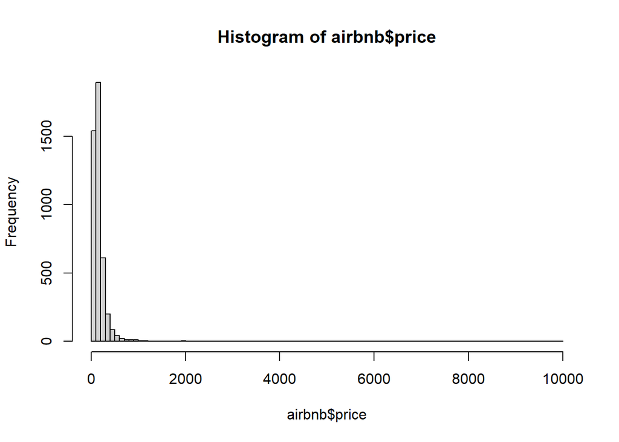

```r
hist(airbnb$price, breaks = 100)
```

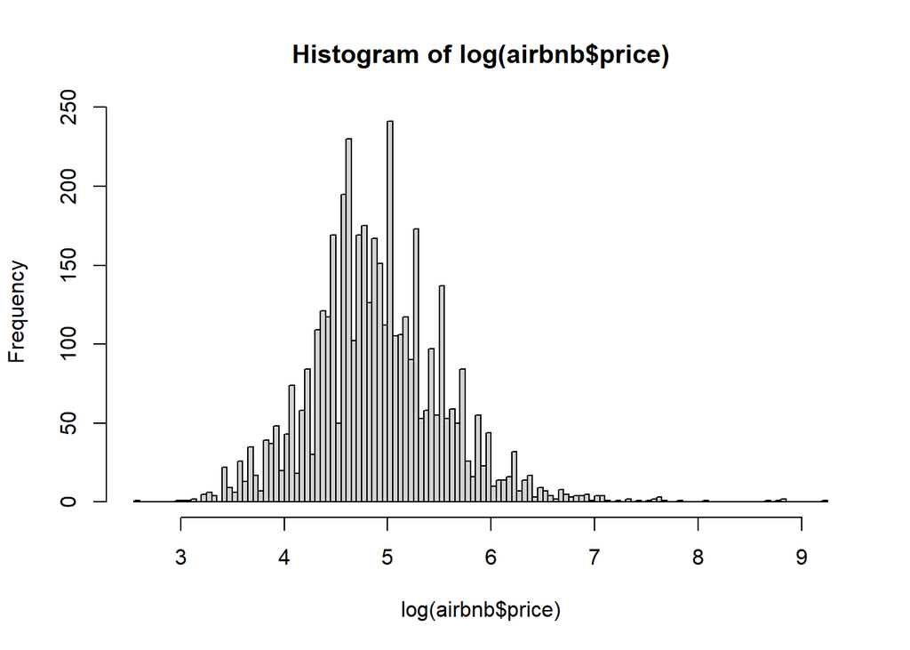

```r
hist(log(airbnb$price), breaks = 100)  # histogram for log(price)
```

### 2.4 Convert the number of bedrooms into another variable with a limited number of categories only, such as 0, 1, 2, 3+, and use these categories in the models below.

```r
airbnb$bedrooms_new <- cut(airbnb$bedrooms, breaks = c(0,1,2,3,Inf), labels=c("0","1", "2", "3+"), include.lowest = TRUE)  #using cut function to create multiple cuts for a categorical variable.
head(airbnb,10)
```

```
##    price bedrooms       room_type accommodates  price1 bedrooms_new
## 1    158        2 Entire home/apt            5 $158.00            1
## 2    150        0 Entire home/apt            4 $150.00            0
## 3     85        1 Entire home/apt            2  $85.00            0
## 4    149        1 Entire home/apt            2 $149.00            0
## 5    150        1 Entire home/apt            4 $150.00            0
## 6    350        2 Entire home/apt            4 $350.00            1
## 7    100        3 Entire home/apt            6 $100.00            2
## 8     94        1 Entire home/apt            2  $94.00            0
## 9     50        1    Private room            2  $50.00            0
## 10    85        1    Private room            2  $85.00            0
```

### 2.5 Now estimate a linear regression model where you explain log price with number of BR-s (the BR categories you did above). Interpret the results. Which model behaves better in the sense of R2?

First trying without log transformation:

```r
m2 <- lm(price ~ bedrooms_new, data=airbnb)
summary(m2)
```

```
##
## Call:
## lm(formula = price ~ bedrooms_new, data = airbnb)
##
## Residuals:
##    Min     1Q Median     3Q    Max
## -577.3  -60.6  -28.4   21.6 9870.6
##
## Coefficients:
##                Estimate Std. Error t value Pr(>|t|)
## (Intercept)     128.385      5.214  24.621  < 2e-16 ***
## bedrooms_new1    65.680      9.605   6.838 9.12e-12 ***
## bedrooms_new2   178.260     14.784  12.058  < 2e-16 ***
## bedrooms_new3+  473.944     22.582  20.988  < 2e-16 ***
## ---
## Signif. codes:  0 '***' 0.001 '**' 0.01 '*' 0.05 '.' 0.1 ' ' 1
##
## Residual standard error: 273.5 on 4444 degrees of freedom
## Multiple R-squared:  0.1108, Adjusted R-squared:  0.1102
## F-statistic: 184.6 on 3 and 4444 DF,  p-value: < 2.2e-16
```

With log transformation:

```r
m <- lm(log(price) ~ bedrooms_new, data=airbnb)
summary(m)
```

```
##
## Call:
## lm(formula = log(price) ~ bedrooms_new, data = airbnb)
##
## Residuals:
##     Min      1Q  Median      3Q     Max
## -2.8379 -0.3273 -0.0316  0.3344  4.5542
##
## Coefficients:
##                Estimate Std. Error t value Pr(>|t|)
## (Intercept)     4.65602    0.01026  453.78   <2e-16 ***
## bedrooms_new1   0.49957    0.01890   26.43   <2e-16 ***
## bedrooms_new2   0.84664    0.02909   29.10   <2e-16 ***
## bedrooms_new3+  1.40077    0.04444   31.52   <2e-16 ***
## ---
## Signif. codes:  0 '***' 0.001 '**' 0.01 '*' 0.05 '.' 0.1 ' ' 1
##
## Residual standard error: 0.5383 on 4444 degrees of freedom
## Multiple R-squared:  0.3135, Adjusted R-squared:  0.3131
## F-statistic: 676.6 on 3 and 4444 DF,  p-value: < 2.2e-16
```

### 2.6 What kind of values do these two variables take? Show the counts! Hint: use function table.

room_type takes character value and accommodates takes integer values.

```r
class(airbnb$room_type)
```

```
## [1] "character"
```

```r
table(airbnb$room_type)
```

```
##
## Entire home/apt      Hotel room    Private room     Shared room
##            3582               4             854               8
```

```r
class(airbnb$accommodates)
```

```
## [1] "integer"
```

```r
table(airbnb$accommodates)
```

```
##
##    1    2    3    4    5    6    7    8    9   10   11   12   13   14   15   16
##  288 1699  462 1108  247  412   61  101    8   27    5   14    3    7    1    5
```

### 2.7 Convert the room type into 3 categories: Entire home/apt, Private room, Other; and recode accommodates into 3 categories: “1”, “2”, “3 or more”.

```r
airbnb <- airbnb %>% mutate(room_type_new = ifelse(room_type %in% "Entire home/apt","Entire home/apt",ifelse(room_type %in% "Private room","Private room","Others")))

airbnb$accommodates_new <- cut(airbnb$accommodates, breaks = c(-Inf,1,2,3,Inf), labels=c("1","2", "3+", "3+"))
```

### 2.8 Now amend your previous model with these two variables (the 3-category version you did above). Interpret and comment the more interesting/important results. Do not forget to explain what are the relevant reference categories and R2.

```r
m3 <- lm(log(price) ~ bedrooms_new+room_type_new+accommodates_new, data=airbnb)
summary(m3)
```

```
##
## Call:
## lm(formula = log(price) ~ bedrooms_new + room_type_new + accommodates_new,
##     data = airbnb)
##
## Residuals:
##     Min      1Q  Median      3Q     Max
## -2.8492 -0.3129 -0.0514  0.2553  4.8515
##
## Coefficients:
##                           Estimate Std. Error t value Pr(>|t|)
## (Intercept)                4.44900    0.03527 126.142   <2e-16 ***
## bedrooms_new1              0.26963    0.02162  12.474   <2e-16 ***
## bedrooms_new2              0.60410    0.02993  20.187   <2e-16 ***
## bedrooms_new3+             1.15680    0.04288  26.975   <2e-16 ***
## room_type_newOthers       -0.11916    0.14357  -0.830    0.407
## room_type_newPrivate room -0.39666    0.02250 -17.631   <2e-16 ***
## accommodates_new2          0.30636    0.03408   8.989   <2e-16 ***
## accommodates_new3+         0.46223    0.03801  12.162   <2e-16 ***
## ---
## Signif. codes:  0 '***' 0.001 '**' 0.01 '*' 0.05 '.' 0.1 ' ' 1
##
## Residual standard error: 0.4922 on 4440 degrees of freedom
## Multiple R-squared:  0.4266, Adjusted R-squared:  0.4257
## F-statistic: 471.9 on 7 and 4440 DF,  p-value: < 2.2e-16
```

### 2.9 You should see that type “Other” is not statistically significant. What does this mean? Why do you think this is the case?

From the above model we can interpret that the category of room type other has a high p value (>0.05) and hence it is not statistically significant. I think this is because of the less number of values in the “other” cactegory as it has only 12 entries compared to rest of all categories.

### 2.10 Now use the model above to predict (log) price for each listing in your data.

```r
pred <- predict(m3)
```

### 2.11 Compute root-mean-squared-error (RMSE) of your predictions.

```r
sqrt(mean((log(airbnb$price) - pred)^2))
```

```
## [1] 0.4917296
```

### 2.12 Now use your model to predict log price for a 2-bedroom apartment that accommodates 4 (i.e. a full 2BR apartment)

```r
new <- data.frame(bedrooms_new="2", accommodates_new="3+", room_type_new="Entire home/apt")
predict(m3, newdata=new)
```

```
##        1
## 5.515337
```